**Machine Learning for Mechanical Engineering**  
**Homework 08 - Solution**

Instructor: Prof. Seungchul Lee  
http://iai.postech.ac.kr/  
Industrial AI Lab at POSTECH

# Problem 4

To deal with nonlinearly distributed data set, we need to design an appropriate kernel to make (or map) the original data to be linearly seperable. However, in artificial neural networks, this step is not necessary. Discuss why. (Hint: see the following figure.)

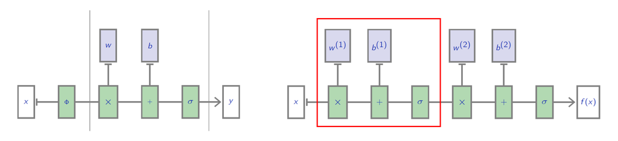

# Solution 4

It is necessary to design appropriate kernels to make linear model work in nonlinear settings by extracting features from nonlinear data. However, in the case of ANN, this kernel is composed of MLP so that the MLP can learn features that can differentiate nonlinear data linearly by itself. Therefore, there is no need to design a kernel function in ANN.

# Problem 5

To train neural networks, backpropagation is used. Briefly explain what the backpropagation is. When you discuss it, use the keywords such as recursive, memorized, dynamic programming, chain rule, etc.

# Solution 5

The backpropagation is a dynamic programming because it memorizes the gradients and reuse them to solve the gradients of the next layer recursively.

# Problem 7

1) Classify the given four points into two classes in 2D plane using a single layer structure as shown below. Plot a linear boundary even if it fails to classify them.

$\;\;\,$ Note that bias units are not indicated here.

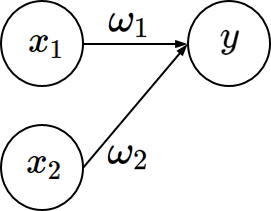

2) Classify the given four points in 2D plane using two layers as shown below.

$\;\;\,$ Note that bias units are not indicated here.

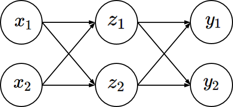

# Solution 7

1) Classify the given four points into two classes in 2D plane using a single layer structure as shown below. Plot a linear boundary even if it fails to classify them.

$\;\;\,$ Note that bias units are not indicated here.

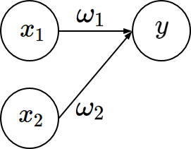

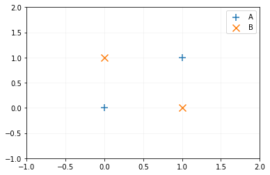

```python
import warnings
warnings.filterwarnings('ignore')
import numpy as np
import matplotlib.pyplot as plt
%matplotlib inline

x_data = np.array([[0, 0], [1, 1], [0, 1], [1, 0]], dtype=np.float32)
y_data = np.array([[0], [0], [1], [1]], dtype=np.float32)

plt.scatter(x_data[:2,0], x_data[:2,1], marker='+', s=100, label='A')
plt.scatter(x_data[2:,0], x_data[2:,1], marker='x', s=100, label='B')
plt.xlim([-1, 2]); plt.ylim([-1, 2]); plt.grid(alpha=0.15); plt.legend();
plt.show()
```

```
[[-1.05704193e-05]
 [-7.21788685e-06]]
```

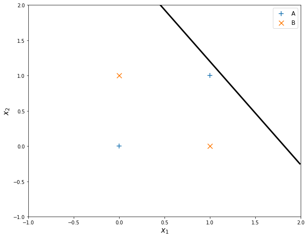

```python
# solution
from sklearn.neural_network import MLPClassifier

clf = MLPClassifier(solver='lbfgs', hidden_layer_sizes=(), activation = 'tanh', max_iter = 100000, learning_rate_init = 0.05)
clf.fit(x_data, y_data)

w_hat = clf.coefs_[0]
b_hat = clf.intercepts_[0]
print(w_hat)


x1p = np.arange(-1, 2, 0.01).reshape(-1, 1)
x2p = - w_hat[0,0]/w_hat[1,0]*x1p - b_hat[0]/w_hat[1,0]

plt.figure(figsize=(10, 8))
plt.scatter(x_data[:2,0], x_data[:2,1], marker='+', s=100, label='A')
plt.scatter(x_data[2:,0], x_data[2:,1], marker='x', s=100, label='B')
plt.legend()

plt.plot(x1p, x2p, 'k', linewidth = 3, label = '')
plt.xlim([0, 8])
plt.xlabel('$x_1$', fontsize = 15)
plt.ylabel('$x_2$', fontsize = 15)
plt.legend(loc = 1, fontsize = 12)
plt.ylim(-1, 2)
plt.xlim(-1, 2)
plt.show()
```

2) Classify the given four points in 2D plane using two layers as shown below.

$\;\;\,$ Note that bias units are not indicated here.

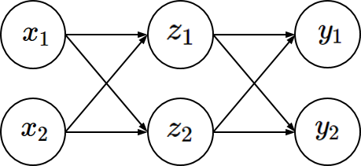

```
[[11.12697296  4.58781512]
 [11.04119089  4.70794598]]
```

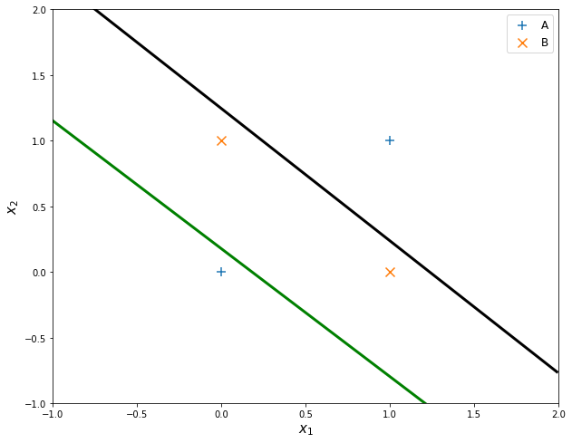

```
[0. 0. 1. 1.]
[[0.]
 [0.]
 [1.]
 [1.]]
```

```python
# Solution
from sklearn.neural_network import MLPClassifier

clf = MLPClassifier(solver='lbfgs',
                    activation='logistic',
                    alpha=0.0,
                    hidden_layer_sizes=(2,),
                    learning_rate_init=0.1,
                    max_iter=1000,
                    random_state=20)
clf.fit(x_data, y_data)


w_hat = clf.coefs_[0]
b_hat = clf.intercepts_[0]
print(w_hat)


x1p = np.arange(-1, 2, 0.01).reshape(-1, 1)
x2p = - w_hat[0,0]/w_hat[1,0]*x1p - b_hat[0]/w_hat[1,0]
x3p = - w_hat[0,1]/w_hat[1,1]*x1p - b_hat[1]/w_hat[1,1]

plt.figure(figsize=(10, 8))
plt.scatter(x_data[:2,0], x_data[:2,1], marker='+', s=100, label='A')
plt.scatter(x_data[2:,0], x_data[2:,1], marker='x', s=100, label='B')


plt.plot(x1p, x2p, 'k', linewidth = 3, label = '')
plt.plot(x1p, x3p, 'g', linewidth = 3, label = '')
plt.xlim([0, 8])
plt.xlabel('$x_1$', fontsize = 15)
plt.ylabel('$x_2$', fontsize = 15)
plt.legend(loc = 1, fontsize = 12)
plt.ylim(-1, 2)
plt.xlim(-1, 2)
plt.show()
print(clf.predict(x_data))
print(y_data)
```

# Problem 8

1) In the problem 7-2), the first layer can be seen as kernel function $\phi$. Show the location of four points on 2D plane after the first layer.

2) Visualize the kernel space onto 2D plane.

$\;\;\,$ Hint: Make 2d grid points and apply the kernel.

3) Plot the decision boundary on kernel space.

# Solution 8

1) In the problem 7-2), the first perceptron layer can be seen as kernel function $\phi$. Show the location of four points on 2D plane after the first layer.

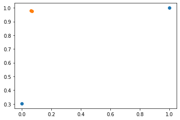

```python
w_hat = np.asmatrix(w_hat)

results = x_data*w_hat + b_hat
results = 1/(1 + np.exp(-results))
plt.scatter([results[0:2,0]], [results[:2,1]], label = '0')
plt.scatter([results[2:,0]], [results[2:,1]], label = '1')
```

2) Visualize the kernel space onto 2D plane.

$\;\;\,$ Hint: Make 2d grid points and apply kernel.

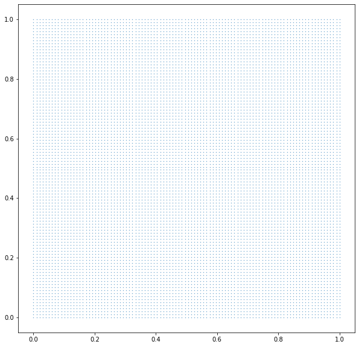

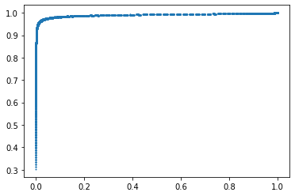

```python
# Solution
xp = np.linspace(0, 1, 100)
yp = np.linspace(0, 1, 100)
grid = np.meshgrid(xp, yp)
grid = np.asarray(grid)
plt.figure(figsize = (10,10))
plt.scatter(grid[0][:], grid[1][:], s = 0.1)
plt.show()
grid = grid.reshape(2, 10000).T
results = grid*w_hat + b_hat
results = 1/(1 + np.exp(-results))
plt.scatter([results[:,0]], [results[:,1]], s = 1)
plt.show()
```

[figure not shown]

```python
grid = grid.reshape(2, 400).T
grid_z = grid*w_hat + b_hat
grid_z = 1/(1 + np.exp(-grid_z))

plt.figure(figsize = (8,6))
plt.scatter([grid_z[:,0]], [grid_z[:,1]], s = 1)
plt.axis('equal')
plt.grid(alpha = 0.15)
plt.show()
```

3) Plot the decision boundary on kernel space.

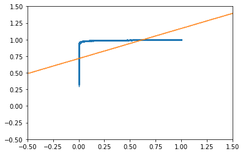

```python
# Solution

w_hat = clf.coefs_[1]
b_hat = clf.intercepts_[1]
xp = np.linspace(-0.5,1.5, 1000).reshape(-1,1)
yp = - w_hat[0,0]/w_hat[1,0]*xp - b_hat[0]/w_hat[1,0]
plt.scatter([results[:,0]], [results[:,1]], s = 1)

plt.scatter(xp, yp, s = 0.1)

plt.ylim(-0.5, 1.5)
plt.xlim(-0.5, 1.5)
plt.show()
```

# Problem 9

Here, we will solve the same problem that we covered in class

1) Classify the above given data using `MLPClassifier` in 2D plane with the hidden layer of size of 3 as shown below.

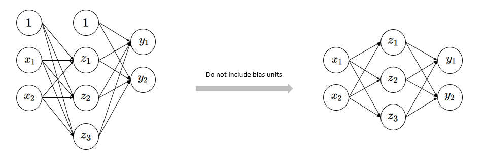

2) Plot those data in Z-plane (hidden layer)

3) Plot 2D hyperplane that separates those data into C1 and C0

# Solution 9

Here, we will solve the same problem that we covered in class.

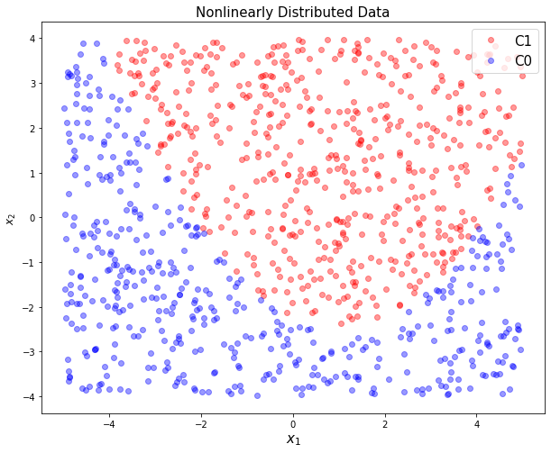

```python
from sklearn.preprocessing import OneHotEncoder

m = 1000
x1 = 10*np.random.rand(m, 1) - 5
x2 = 8*np.random.rand(m, 1) - 4

g = - 0.5*(x1-1)**2 + 2*x2 + 5

C1 = np.where(g >= 0)[0]
C0 = np.where(g < 0)[0]
N = C1.shape[0]
M = C0.shape[0]
m = N + M

X1 = np.hstack([x1[C1], x2[C1]])
X0 = np.hstack([x1[C0], x2[C0]])

train_X = np.vstack([X1, X0])
train_X = np.asmatrix(train_X)

train_y = np.vstack([np.ones([N,1]), np.zeros([M,1])])
ohe = OneHotEncoder(handle_unknown='ignore')
train_y = ohe.fit_transform(train_y).toarray()

plt.figure(figsize=(10, 8))
plt.plot(x1[C1], x2[C1], 'ro', alpha = 0.4, label = 'C1')
plt.plot(x1[C0], x2[C0], 'bo', alpha = 0.4, label = 'C0')
plt.title('Nonlinearly Distributed Data', fontsize = 15)
plt.legend(loc = 1, fontsize = 15)
plt.xlabel(r'$x_1$', fontsize = 15)
plt.ylabel(r'$x_2$', fontsize = 12)
plt.show()
```

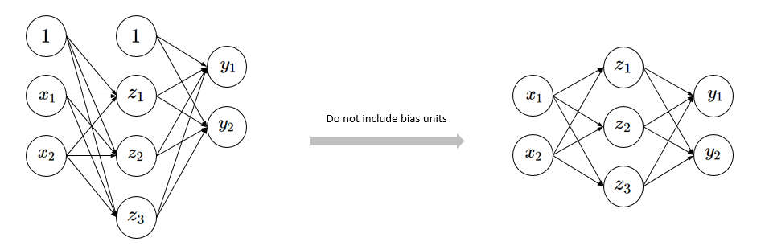

```python
clf = MLPClassifier(solver = 'sgd',
                    hidden_layer_sizes = (3,),
                    activation = 'logistic',
                    max_iter = 50000,
                    learning_rate_init = 0.01)

clf.fit(train_X, train_y)
```

```
MLPClassifier(activation='logistic', alpha=0.0001, batch_size='auto',
       beta_1=0.9, beta_2=0.999, early_stopping=False, epsilon=1e-08,
       hidden_layer_sizes=(3,), learning_rate='constant',
       learning_rate_init=0.01, max_iter=50000, momentum=0.9,
       n_iter_no_change=10, nesterovs_momentum=True, power_t=0.5,
       random_state=None, shuffle=True, solver='sgd', tol=0.0001,
       validation_fraction=0.1, verbose=False, warm_start=False)
```

```python
w_hat = clf.coefs_[0]
b_hat = clf.intercepts_[0]
```

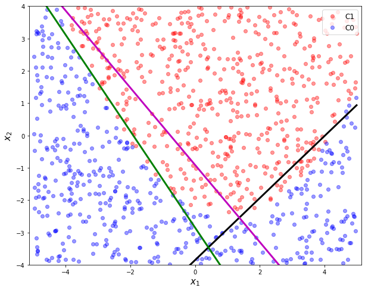

```python
x1p = np.arange(-5, 5, 0.01).reshape(-1, 1)
x2p = - w_hat[0,0]/w_hat[1,0]*x1p - b_hat[0]/w_hat[1,0]
x3p = - w_hat[0,1]/w_hat[1,1]*x1p - b_hat[1]/w_hat[1,1]
x4p = - w_hat[0,2]/w_hat[1,2]*x1p - b_hat[2]/w_hat[1,2]

plt.figure(figsize = (10, 8))
plt.plot(x1[C1], x2[C1], 'ro', alpha = 0.4, label = 'C1')
plt.plot(x1[C0], x2[C0], 'bo', alpha = 0.4, label = 'C0')
plt.plot(x1p, x2p, 'k', linewidth = 3, label = '')
plt.plot(x1p, x3p, 'g', linewidth = 3, label = '')
plt.plot(x1p, x4p, 'm', linewidth = 3, label = '')
plt.xlabel('$x_1$', fontsize = 15)
plt.ylabel('$x_2$', fontsize = 15)
plt.legend(loc = 1, fontsize = 12)
plt.axis('equal')
plt.xlim([-5, 5])
plt.ylim([-4, 4])
plt.show()
```

```python
H = train_X*w_hat + b_hat
H = 1/(1 + np.exp(-H))
```

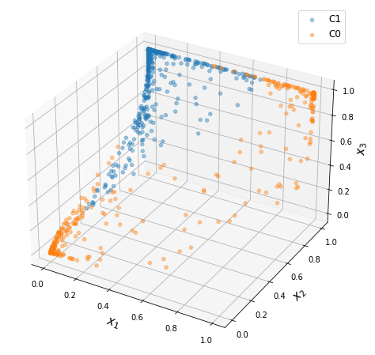

```python
import numpy as np
import matplotlib.pyplot as plt
from mpl_toolkits.mplot3d import Axes3D

fig = plt.figure(figsize = (10, 8))
ax = fig.add_subplot(1, 1, 1, projection = '3d')

x1 = H[0:N,0]
y1 = H[0:N,1]
z1 = H[0:N,2]

x0 = H[N:m,0]
y0 = H[N:m,1]
z0 = H[N:m,2]

ax.scatter(x1, y1, z1, 'ro', alpha = 0.4, label = 'C1')
ax.scatter(x0, y0, z0, 'bo', alpha = 0.4, label = 'C0')

ax.set_xlabel('$x_1$', fontsize = 15)
ax.set_ylabel('$x_2$', fontsize = 15)
ax.set_zlabel('$x_3$', fontsize = 15)
# ax.view_init(30,30)
plt.legend(fontsize = 12)
plt.show()
```

```python
w_hat = clf.coefs_[1]
b_hat = clf.intercepts_[1]
```

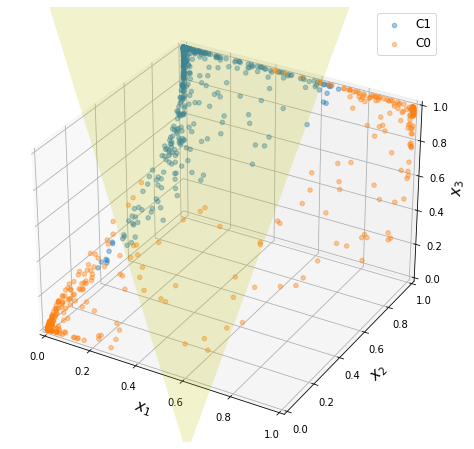

```python
fig = plt.figure(figsize = (10, 8))
ax = fig.add_subplot(1, 1, 1, projection = '3d')

xp = np.arange(0, 1, 0.01).reshape(-1, 1)
yp = np.arange(0, 1, 0.01).reshape(-1, 1)

xp, yp = np.meshgrid(xp, yp)

z1p = - (w_hat[0,0]/w_hat[2,0])*xp - (w_hat[1,0]/w_hat[2,0])*yp - b_hat[0]/w_hat[2,0]
z2p = - (w_hat[0,1]/w_hat[2,1])*xp - (w_hat[1,1]/w_hat[2,1])*yp - b_hat[1]/w_hat[2,1]

x1 = H[0:N,0]
y1 = H[0:N,1]
z1 = H[0:N,2]

x0 = H[N:m,0]
y0 = H[N:m,1]
z0 = H[N:m,2]

ax.scatter(x1, y1, z1, 'ro', alpha = 0.4, label = 'C1')
ax.scatter(x0, y0, z0, 'bo', alpha = 0.4, label = 'C0')
ax.plot_surface(xp, yp, z1p, color = 'y', alpha = 0.2, shade = False)
# ax.plot_surface(xp, yp, z2p, color = 'g', alpha = 0.2, shade = False)
ax.set_xlabel('$x_1$', fontsize = 15)
ax.set_ylabel('$x_2$', fontsize = 15)
ax.set_zlabel('$x_3$', fontsize = 15)
ax.set_xlim(0,1)
ax.set_ylim(0,1)
ax.set_zlim(0,1)
# ax.view_init(30,30)
plt.legend(fontsize = 12)
plt.show()
```

# Problem 11

[hand-written] Suppose a multi-layer perceptron which has an input layer with 10 neurons, a hidden layer with 50 neurons, and an output layer with 3 neurons. Non-linear activation function for every neurons are ReLU. Write your answer to the following questions.

(1) Size of input X ?

(2) Size of weights and biases ( Wh,bh ) for the hidden layer?

(3) Size of weights and biases ( Wo,bo ) for the output layer?

(4) Size of output Y ?

# Solution 11

(1) 10  
(2) (500,1)  
(3) (150,1)  
(4) 3